# Comparing Drop-sec and DroNq-sec

## 1. Expression Matrix S1

We begin by loading the dataframe which contains our single-cell expression data. The `dim` function returns us the number of genes and the number of cells, respectively.

```r
setwd('/Users/aselewa/oni-data/')
library(Seurat)
library(dplyr)
library(Matrix)

S1.data <- read.table('reads.293FTDR_S1_R1_001.fastq_bq10_star_corrected.umi.dge.txt',sep='\t',header=TRUE,row.names=1)
dim(S1.data)
```

```
## [1] 22257  1757
```

We create a Seurat object, where we automatically filter cells that contain less than 200 genes. We also remove genes that are present in less than 3 cells. These numbers were chosen such that ~1% of the data is filtered. These numbers can be improved if ERCC data is provided.

```r
s1 <- CreateSeuratObject(raw.data = S1.data, project="S1",min.genes = 200,min.cells = 3)
```

We plot the number of genes vs total counts for each cell. We expect these values to be strongly correlated, thus we can easily identify outliers. We identify the outliers by looking at data points in the plot that deviate from the ensemble trend. After identifying outliers, we remove them with the `FilterCells()` function. We also normalize the data and standardize it.

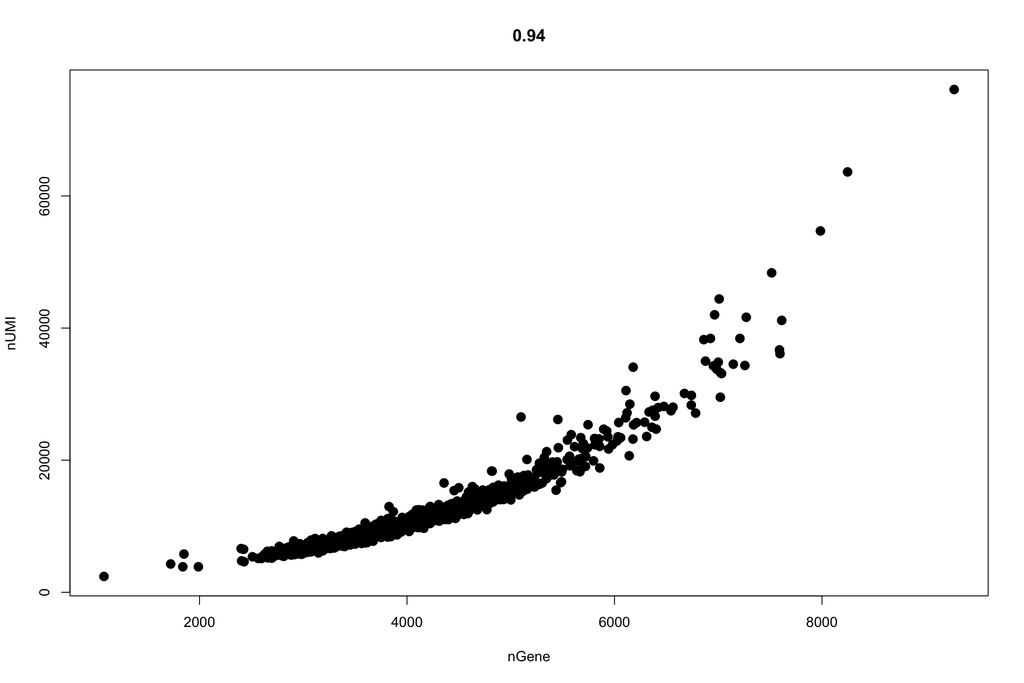

```r
GenePlot(s1,gene1='nGene',gene2='nUMI')
```

```r
s1 <- FilterCells(object = s1,subset.names = c('nGene','nUMI'),low.thresholds = c(0,0),high.thresholds = c(7000,40000))
s1 <- NormalizeData(s1,normalization.method = "LogNormalize",scale.factor = 10000)
s1 <- ScaleData(s1,vars.to.regress = 'nUMI',display.progress = FALSE)
```

Next, we run linear dimensionality reduction using all the genes. The plot below allows us to choose the optimal number of principle components to use for clustering. The elbow in the plot is approximately 7.

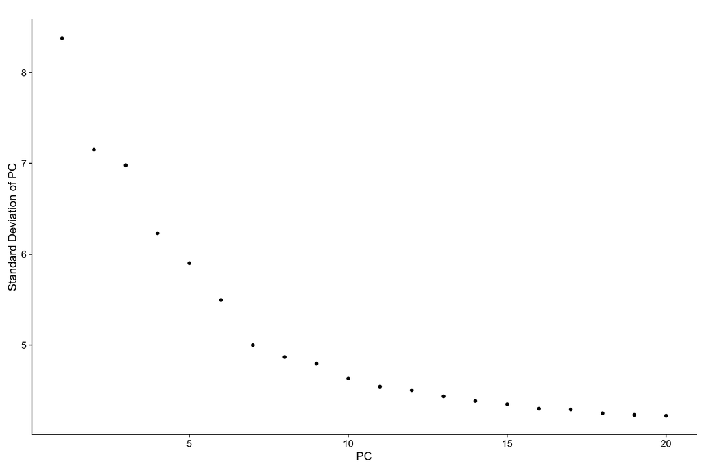

```r
s1 <- RunPCA(object = s1, pc.genes = row.names(s1@raw.data),do.print = FALSE)
PCElbowPlot(s1)
```

We cluster the cells using 7 principle components. The resolution parameter was tuned until non-overlapping clusters were formed. We also run non-linear dimensionality reduction for visualization.

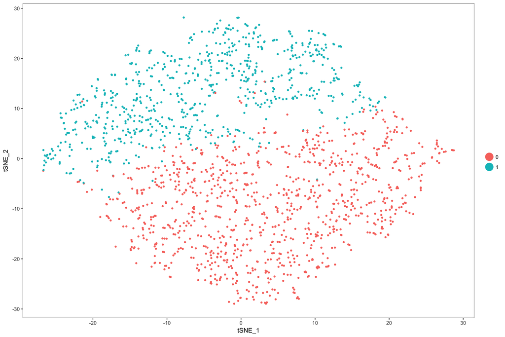

```r
s1 <- FindClusters(s1,reduction.type = "pca", dims.use = 1:7,
                      resolution= 0.3, print.output = 0,force.recalc = TRUE)
s1 <- RunTSNE(s1,dims.use=1:7)
TSNEPlot(s1)
```

```r
save(s1,file='s1_seurat_object.Robj')
```

To test the quality of these two clusters, we find the biomarkers that define the clusters. We take the top 10 biomarkers from each cluster and plot their distribution across the clusters.

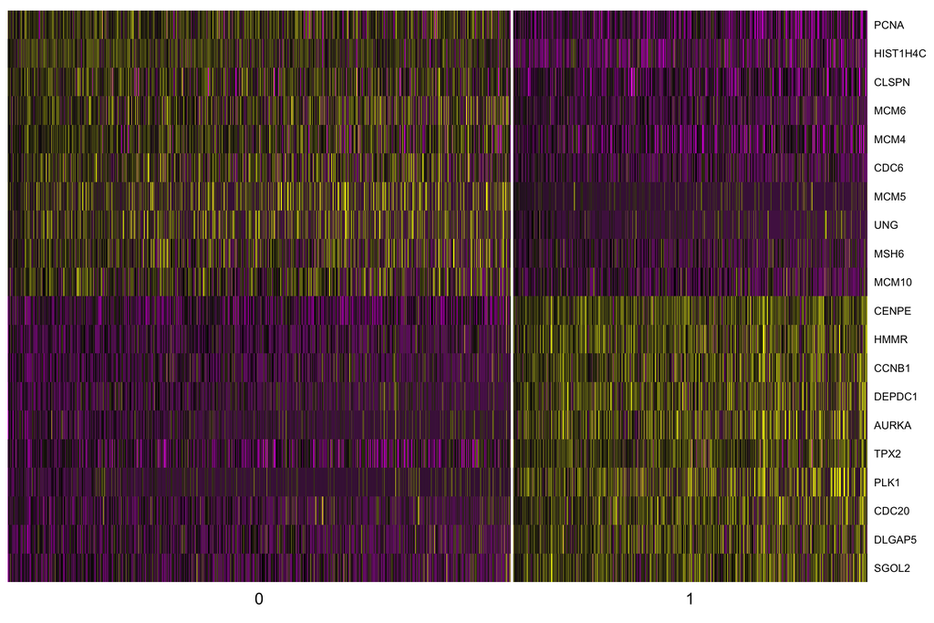

```r
markers <- FindAllMarkers(s1, only.pos = TRUE, min.pct = 0.25,thresh.use = 0.25,print.bar = FALSE)
top10 <- markers %>% group_by(cluster) %>% top_n(10,avg_diff)
DoHeatmap(s1, genes.use = top10$gene,remove.key = TRUE, slim.col.label = TRUE)
```

From the heatmap, it is clear that we have atleast 10 genes that are significally differentially clustered: The p-value for this differential expression is significant for these genes, which can be seen in the table below.

```r
top10
```

```
## # A tibble: 20 x 6
## # Groups:   cluster [2]
##            p_val  avg_diff pct.1 pct.2 cluster     gene
##            <dbl>     <dbl> <dbl> <dbl>  <fctr>    <chr>
##  1 1.716404e-121 0.6682952 0.948 0.759       0     PCNA
##  2 5.043014e-114 0.9353015 0.988 0.911       0 HIST1H4C
##  3  4.508589e-81 0.5805645 0.973 0.915       0    CLSPN
##  4  1.005641e-78 0.5719654 0.775 0.453       0     MCM6
##  5  2.459160e-76 0.4957667 0.950 0.836       0     MCM4
##  6  9.678165e-75 0.5459092 0.785 0.498       0     CDC6
##  7  7.420265e-55 0.4177949 0.509 0.185       0     MCM5
##  8  2.411899e-52 0.4384818 0.586 0.292       0      UNG
##  9  7.109948e-47 0.4248232 0.713 0.524       0     MSH6
## 10  7.265283e-47 0.4203994 0.785 0.570       0    MCM10
## 11 4.950553e-183 0.9972852 0.985 0.761       1    CENPE
## 12 5.263906e-160 0.8648117 0.905 0.501       1     HMMR
## 13 3.503511e-148 0.8089304 0.894 0.506       1    CCNB1
## 14 7.141456e-140 0.7797554 0.846 0.425       1   DEPDC1
## 15 5.323556e-124 0.7845431 0.783 0.350       1    AURKA
## 16 5.209915e-122 0.6464489 0.972 0.818       1     TPX2
## 17 3.298280e-117 0.6527943 0.704 0.255       1     PLK1
## 18 3.319611e-114 0.6677229 0.868 0.489       1    CDC20
## 19 1.221014e-111 0.6631115 0.886 0.572       1   DLGAP5
## 20 1.212896e-107 0.6406025 0.901 0.575       1    SGOL2
```

## 2. Expression Matrix S2

We now load the saved Seurat object for S2 and plot the tSNE for it.

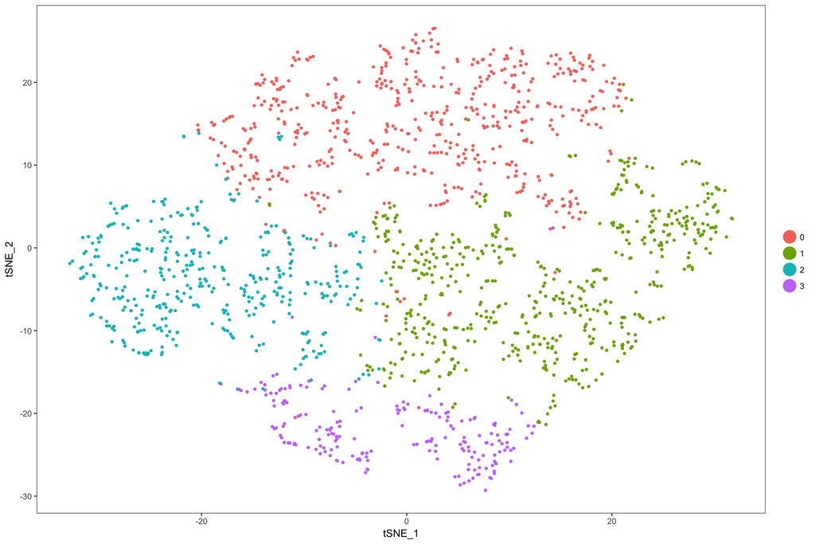

```r
load('S2_seurat_object.Robj')
TSNEPlot(s2)
```

Next, we find biomarkers as before and plot the top 10 differentially expressed markers.

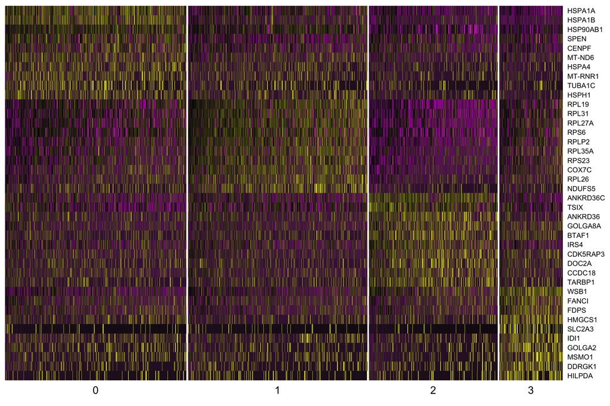

```r
markers_s2 <- FindAllMarkers(s2, only.pos = TRUE, min.pct = 0.25,thresh.use = 0.25,print.bar = FALSE)
top10_s2 <- markers_s2 %>% group_by(cluster) %>% top_n(10,avg_diff)
DoHeatmap(s2, genes.use = top10_s2$gene,remove.key = TRUE, slim.col.label = TRUE,cex.col = 0.5)
```

We can also look at the top 3 expressed genes to reduce some noise.

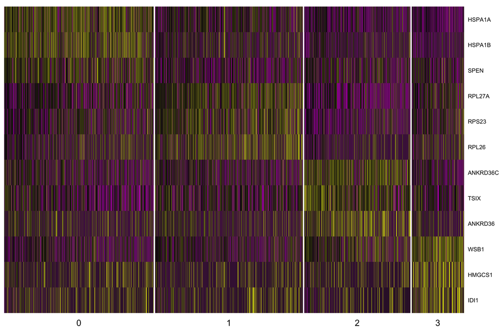

```r
top3_s2 <- markers_s2 %>% group_by(cluster) %>% top_n(3,avg_diff)
DoHeatmap(s2, genes.use = top3_s2$gene, remove.key = TRUE,slim.col.label = TRUE)
```

The corresponding p-values for these differentially expressed genes can be seen below:

```r
top3_s2
```

```
## # A tibble: 12 x 6
## # Groups:   cluster [4]
##           p_val  avg_diff pct.1 pct.2 cluster     gene
##           <dbl>     <dbl> <dbl> <dbl>  <fctr>    <chr>
##  1 2.325958e-91 1.0592476 0.890 0.653       0   HSPA1A
##  2 4.202746e-74 0.9971253 0.793 0.452       0   HSPA1B
##  3 6.893121e-33 0.5609748 0.844 0.657       0     SPEN
##  4 3.013376e-49 0.6026764 0.903 0.695       1   RPL27A
##  5 6.996467e-39 0.5926390 0.815 0.613       1    RPS23
##  6 1.941518e-31 0.5949338 0.670 0.433       1    RPL26
##  7 6.379733e-53 0.7809654 0.860 0.594       2 ANKRD36C
##  8 1.352739e-41 0.7850120 0.920 0.778       2     TSIX
##  9 2.481752e-29 0.6902387 0.610 0.368       2  ANKRD36
## 10 2.442754e-56 1.0069666 0.914 0.617       3     WSB1
## 11 1.658476e-25 0.9540196 0.571 0.314       3   HMGCS1
## 12 4.743073e-20 0.7738874 0.551 0.303       3     IDI1
```

## 3. Comparing S1 and S2 clustering results

The table below gives a brief summary yielded by the analysis.

```r
table <- read.table('compare_s1s2.txt',sep='\t',header=TRUE,row.names=1)
table
```

```
##                             S1    S2
## Num Cells                 1757  1735
## Num. Genes               22257 20749
## Effective Dimensionality     7     4
## Clusters Found               2     4
## Num. Diff. Exp. Genes       97   657
```

We have found double the amount of clusters in S2 than we did in S1 using the same resolution parameter of 0.3. This implies that the S2 method is either more noisy or it is more sensitive to changes in expression. This cannot be resolved without control data where we can model the technical noise. There is roughly 6 times more genes that are differentially expressed in S2 compared with S1. Some of these genes are differentially expressed in both datasets:

```r
s1_genes <- markers$gene
s2_genes <- markers_s2$gene

overlap_genes <- s1_genes[!is.na(match(s1_genes,s2_genes))]
overlap_genes
```

```
##  [1] "PCNA"     "HIST1H4C" "CDC6"     "MSH6"     "MCM2"     "POLD3"
##  [7] "CDT1"     "HIST1H1E" "CENPE"    "CKS2"     "KIF14"    "MKI67"
## [13] "KIF23"    "TTK"      "TUBA1C"   "RANGAP1"
```

These are likely to be household genes that are common to all cell types and they exhibit some fluctuation due to the noise of the method being used (totally guessing based on Googling what these genes do.) It is interesting to note that these genes are among the top differentially expressed in S1.

We turn to the top differentially expressed genes that do not overlap.

Top differenttially expressed genes in S1 that do not overlap with any genes found in S2

```r
top10$gene[is.na(match(top10$gene,s2_genes))]
```

```
##  [1] "CLSPN"  "MCM6"   "MCM4"   "MCM5"   "UNG"    "MCM10"  "HMMR"
##  [8] "CCNB1"  "DEPDC1" "AURKA"  "TPX2"   "PLK1"   "CDC20"  "DLGAP5"
## [15] "SGOL2"
```

Top differentially expressed genes in S2 that do not overlap with any genes found in S1

```r
top10_s2$gene[is.na(match(top10_s2$gene,s1_genes))]
```

```
##  [1] "HSPA1A"   "HSPA1B"   "HSP90AB1" "SPEN"     "CENPF"    "MT-ND6"
##  [7] "HSPA4"    "MT-RNR1"  "HSPH1"    "RPL19"    "RPL31"    "RPL27A"
## [13] "RPS6"     "RPLP2"    "RPL35A"   "RPS23"    "COX7C"    "RPL26"
## [19] "NDUFS5"   "ANKRD36C" "TSIX"     "ANKRD36"  "GOLGA8A"  "BTAF1"
## [25] "IRS4"     "CDK5RAP3" "DOC2A"    "CCDC18"   "TARBP1"   "WSB1"
## [31] "FANCI"    "FDPS"     "HMGCS1"   "SLC2A3"   "IDI1"     "GOLGA2"
## [37] "MSMO1"    "DDRGK1"   "HILPDA"
```

S2 has double the clusters, however, we can see that it has more than double the number of differentially expressed genes. Assuming this is not just technical noise, S2 is more sensitive to changes in gene transcription.